# Data Visualization with ggplot2 (Part 2)

Best Practices

Seun Odeyemi

2019-03-23

## Load Libraries

```r
library(readr)
library(dplyr)
library(ggplot2)
library(tidyr)
library(skimr)
library(knitr)
library(kableExtra)
library(RColorBrewer)
library(grid)
library(ggthemes)
library(forcats)
library(GGally)
```

## Best Practices for Graphical Data Representation

In this chapter we will consider common pitfalls and the best way to represent data. This is important both for publications and reports since we want to communicate effectively but also for ourselves since we need to be able to accurately see our data to be able to assess it.

## Bar Plots

There are two types of bar plots.

- The first shows the absolute values in each category.
- The second shows the distribution, which turns out to be incredibly common and equally terrible. Why is that? Let’s return to the Mammalian Sleep dataset.

### Dynamite Bar Plots (Avoid Like a Plague!)

```r
# glimpse(msleep)

data("msleep")

msleep2 <- msleep %>%
  mutate(vore = as_factor(vore,
                          levels = c("carni", "herbi", "omni", "insecti")),
         vore = recode_factor(vore,
         `carni` = "Carnivore",
         `herbi` = "Herbivore",
         `omni` = "Ommivore",
         `insecti` = "Insectivore",
         .default = NA_character_))
str(msleep2)
```

```
#> Classes 'tbl_df', 'tbl' and 'data.frame':    83 obs. of  11 variables:
#>  $ name        : chr  "Cheetah" "Owl monkey" "Mountain beaver" "Greater short-tailed shrew" ...
#>  $ genus       : chr  "Acinonyx" "Aotus" "Aplodontia" "Blarina" ...
#>  $ vore        : Factor w/ 4 levels "Carnivore","Herbivore",..: 1 3 2 3 2 2 1 NA 1 2 ...
#>  $ order       : chr  "Carnivora" "Primates" "Rodentia" "Soricomorpha" ...
#>  $ conservation: chr  "lc" NA "nt" "lc" ...
#>  $ sleep_total : num  12.1 17 14.4 14.9 4 14.4 8.7 7 10.1 3 ...
#>  $ sleep_rem   : num  NA 1.8 2.4 2.3 0.7 2.2 1.4 NA 2.9 NA ...
#>  $ sleep_cycle : num  NA NA NA 0.133 0.667 ...
#>  $ awake       : num  11.9 7 9.6 9.1 20 9.6 15.3 17 13.9 21 ...
#>  $ brainwt     : num  NA 0.0155 NA 0.00029 0.423 NA NA NA 0.07 0.0982 ...
#>  $ bodywt      : num  50 0.48 1.35 0.019 600 ...
```

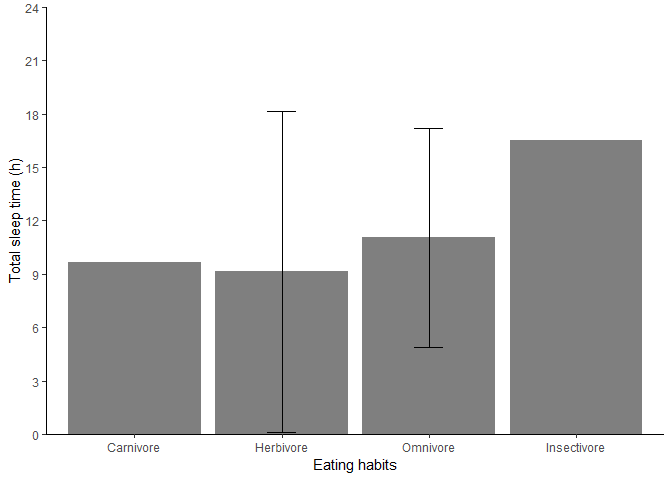

```r
levels(msleep2$vore) <- c("Carnivore", "Herbivore", "Omnivore", "Insectivore")

sleep <- msleep2 %>% select(vore, total = sleep_total, rem = sleep_rem)

sleep <- sleep[complete.cases(sleep), ]

d <- ggplot(sleep, aes(vore, total)) +
  scale_y_continuous("Total sleep time (h)",
                     limits = c(0, 24),
                     breaks = seq(0, 24, 3),
                     expand = c(0, 0)) +
  scale_x_discrete("Eating habits") +
  theme_classic()
d +
  stat_summary(fun.y = mean, geom = "bar",
               fill = "grey50") +
  stat_summary(fun.data = mean_sdl, mult = 1,
               geom = "errorbar", width = 0.2)
```

### Individual Data Points with geom_point()

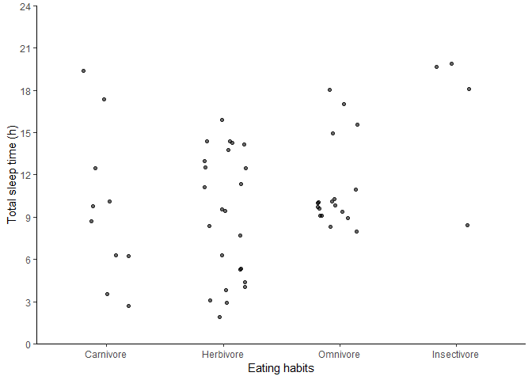

```r
d +
  geom_point(alpha = 0.6, position = position_jitter(width = 0.2))
```

### Errorbar

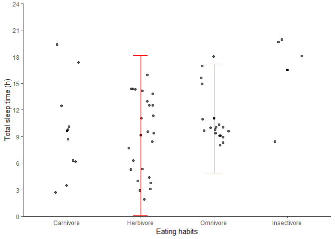

```r
d +
  geom_point(alpha = 0.6, position = position_jitter(width = 0.2)) +
  stat_summary(fun.y = mean, geom = "point", fill = "red") +
  stat_summary(fun.data = mean_sdl, mult = 1, geom = "errorbar",
               width = 0.2, col = "red")
```

### Pointrange

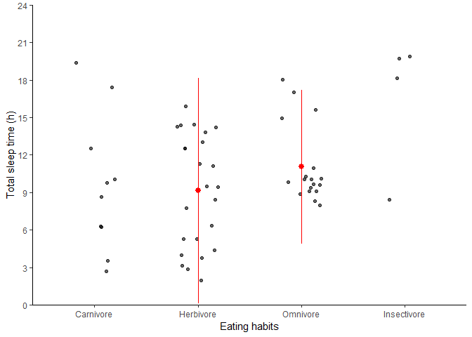

```r
d +
  geom_point(alpha = 0.6, position = position_jitter(width = 0.2)) +
  stat_summary(fun.data = mean_sdl, mult = 1, width = 0.2, col = "red")
```

## Bar Plots(1)

In the video we saw why “dynamite plots” (bar plots with error bars) are not well suited for their intended purpose of depicting distributions. If you really want error bars on bar plots, you can still get that. However, you’ll need to set the positions manually. A point geom will typically serve you much better.

We saw an example of a dynamite plot earlier in this course. Let’s return to that code and make sure you know how to handle it. We’ll use the `mtcars` dataset for examples. The first part of this exercise will just be a refresher, then we’ll get into some details.

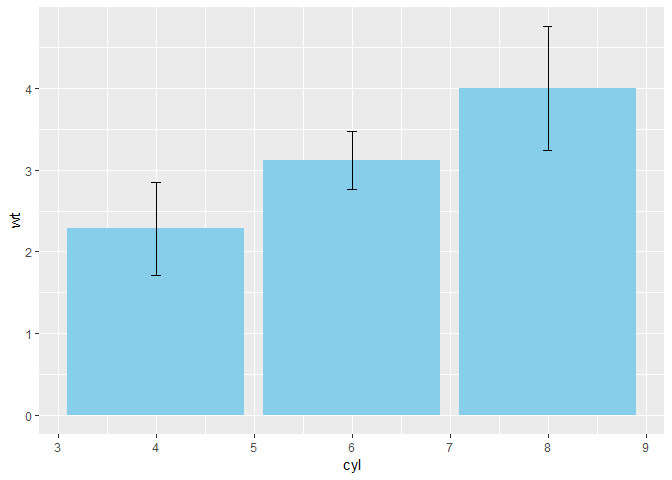

```r
# Base layers
m <- ggplot(mtcars, aes(x = cyl, y = wt))

# Draw dynamite plot
m +
  stat_summary(fun.y = mean, geom =  "bar", fill = "skyblue") +
  stat_summary(fun.data = mean_sdl, fun.args = list(mult = 1), geom = "errorbar", width = 0.1)
```

Good job! Remember, we can specify any function in fun.data or fun.y and we can also specify any geom, as long as it’s appropriate to the data type.

## Bar Plot (2)

In the previous exercise we used the mtcars dataset to draw a dynamite plot about the weight of the cars per cylinder type.

In this exercise we will add a distinction between transmission type, am, for the dynamite plots.

```r
# Base layers
m <- ggplot(mtcars, aes(x = cyl,y = wt, col = am, fill = am))

# Plot 1: Draw dynamite plot
m +
  stat_summary(fun.y = mean, geom = "bar") +
  stat_summary(fun.data = mean_sdl, fun.args = list(mult = 1), geom = "errorbar", width = 0.1)
```

[output not shown]

```r
# Plot 2: Set position dodge in each stat function
m +
  stat_summary(fun.y = mean, geom = "bar", position = "dodge") +
  stat_summary(fun.data = mean_sdl, fun.args = list(mult = 1),
               geom = "errorbar", width = 0.1, position = "dodge")
```

[output not shown]

```r
# Set your dodge posn manually
posn.d <- position_dodge(0.9)

# Plot 3: Redraw dynamite plot
m +
  stat_summary(fun.y = mean, geom = "bar", position = posn.d) +
  stat_summary(fun.data = mean_sdl, fun.args = list(mult = 1), geom = "errorbar", width = 0.1, position = posn.d)
```

[output not shown]

## Bar Plot (3)

If it is appropriate to use bar plots (see the video for a discussion!), then it would also be nice to give an impression of the number of values in each group.

`stat_summary()` doesn’t keep track of the count. `stat_sum()` does (that’s the whole point), but it’s difficult to access. In this case, the most straightforward thing to do is calculate exactly what we want to plot beforehand. For this exercise we’ve created a summary data frame called `mtcars.cyl` which contains the average (wt.avg), standard deviations (sd) and count (n) of car weights, according to cylinders, cyl. It also contains the proportion (prop) of each cylinder represented in the entire dataset. Use the console to familiarize yourself with the mtcars.cyl data frame.

```r
# Create mtcars.cyl
mtcars.cyl <- mtcars %>%
  group_by(cyl)%>%
  summarise(wt.avg = mean(wt),
            sd = sd(wt),
            n = n()) %>%
  mutate(prop = n / sum(n))

glimpse(mtcars.cyl)
```

```
#> Observations: 3
#> Variables: 5
#> $ cyl    <dbl> 4, 6, 8
#> $ wt.avg <dbl> 2.285727, 3.117143, 3.999214
#> $ sd     <dbl> 0.5695637, 0.3563455, 0.7594047
#> $ n      <int> 11, 7, 14
#> $ prop   <dbl> 0.34375, 0.21875, 0.43750
```

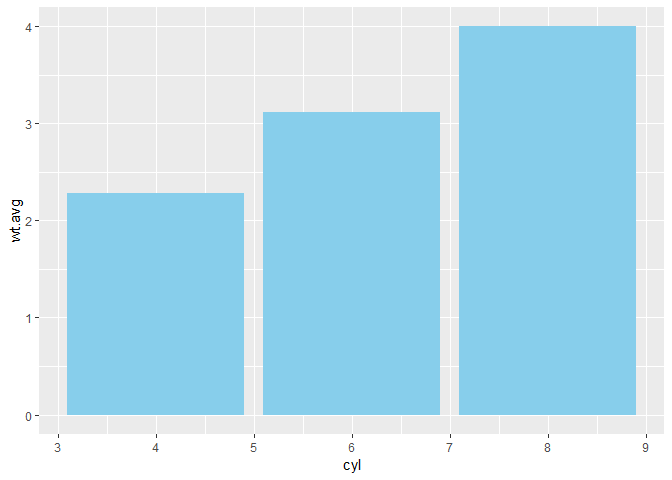

```r
# Base layers
m <- ggplot(mtcars.cyl, aes(x = cyl, y = wt.avg))

# Plot 1: Draw bar plot with geom_bar
m + geom_bar(stat = "identity", fill = "skyblue")
```

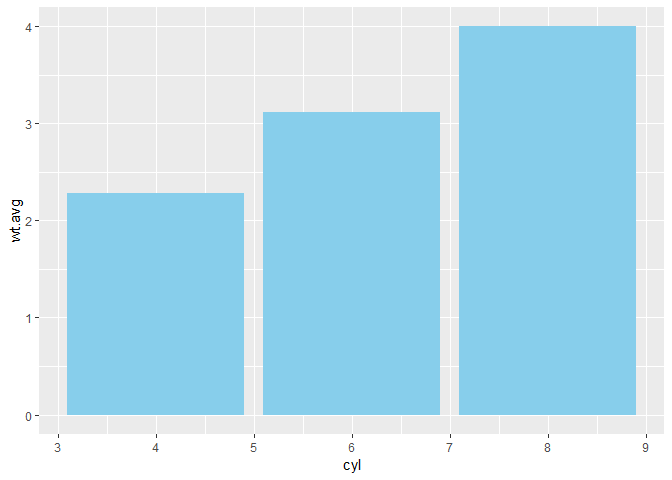

```r
# Plot 2: Draw bar plot with geom_col
m + geom_col(fill = "skyblue")
```

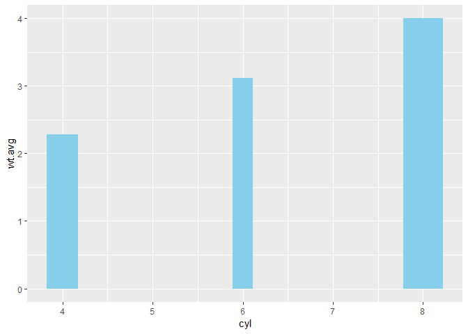

```r
# Plot 3: geom_col with variable widths.
m + geom_col(fill = "skyblue", width = mtcars.cyl$prop)
```

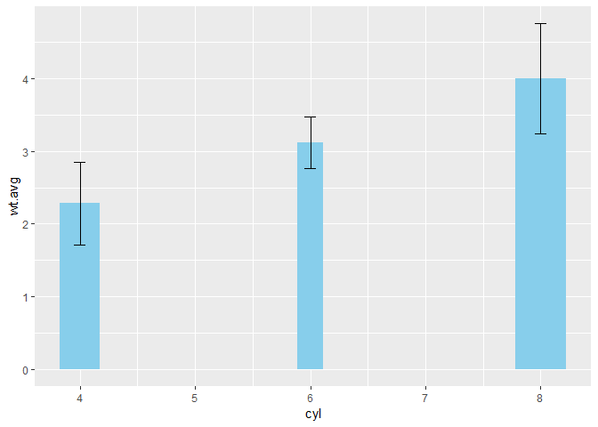

```r
# Plot 4: Add error bars
m + geom_col(fill = "skyblue", width = mtcars.cyl$prop) +
  geom_errorbar(aes(ymin = wt.avg - sd, ymax = wt.avg + sd), width = 0.1)
```

## Pie Charts

In the coordinates chapter we discussed how a pie chart is simply a stacked bar chart plotted onto a polar coordinate. I (Rick) mentioned that pie charts are not going to be your first choice for plotting. So, let’s return to this topic and find out why. When we make a pie chart, the question we are asking is what proportion of a categorical variable is represented by each sub group? That is, parts-of-a-whole type question. The implicit question is if any subgroup are over or under represented, the circle is a perfect symbol of a whole. We inituitively understand it as representing all possible outcomes. It is filled and there is no room for any other possibilities. However, its benefit stop there.

```r
data("HairEyeColor")

glimpse(HairEyeColor)
```

```
#>  'table' num [1:4, 1:4, 1:2] 32 53 10 3 11 50 10 30 10 25 ...
#>  - attr(*, "dimnames")=List of 3
#>   ..$ Hair: chr [1:4] "Black" "Brown" "Red" "Blond"
#>   ..$ Eye : chr [1:4] "Brown" "Blue" "Hazel" "Green"
#>   ..$ Sex : chr [1:2] "Male" "Female"
```

### Pie Charts (1)

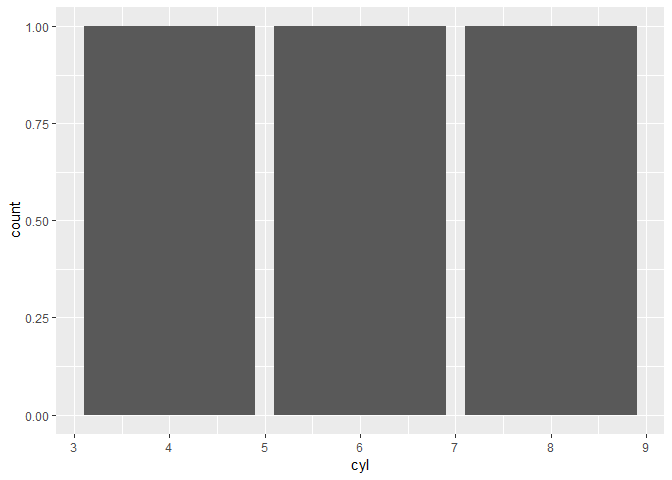

```r
# Bar chart
ggplot(mtcars, aes(x = cyl, fill = am)) +
  geom_bar(position = "fill")
```

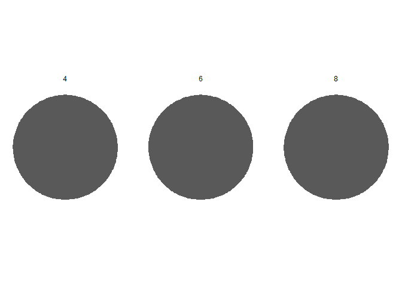

```r
# Convert bar chart to pie chart
ggplot(mtcars, aes(x = factor(1), fill = am)) +
  geom_bar(position = "fill", width = 1) +
  facet_grid(. ~ cyl) + # Facets
  coord_polar(theta = "y") + # Coordinates
  theme_void() # theme
```

### Pie Charts (2)

The trick is to use a parallel coordinates plot, like [this one](https://s3.amazonaws.com/assets.datacamp.com/course/ggplot2/course_2/parallelcoord.png). Each variable is plotted on its own parallel axis. Individual observations are connected with lines, colored according to a variable of interest. This is a surprisingly useful visualization since we can combine many variables, even if they are on entirely different scales.

A word of caution though: typically it is very taboo to draw lines in this way. It’s the reason why we don’t draw lines across levels of a nominal variable - the order, and thus the slope of the line, is meaningless. Parallel plots are a (very useful) exception to the rule!

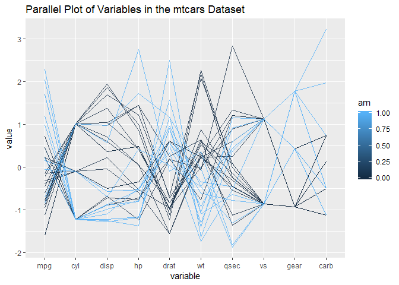

```r
# All columns except am
group_by_am <- 9
my_names_am <- (1:11)[-group_by_am]

# Basic parallel plot - each variable plotted as a z-score transformation
ggparcoord(mtcars, my_names_am, groupColumn = group_by_am, alpha = 0.8) +
  ggtitle("Parallel Plot of Variables in the mtcars Dataset")
```

## Plot Matrix (1)

The parallel coordinate plot from the last exercise is an excellent example of an exploratory plot. It presents a massive amount of information and allows the specialist to explore many relationships all at once. Another great example is a plot matrix (a SPLOM, from scatter plot matrix).

`GGally::ggpairs(mtcars2)` will produce the plot of a selection of the mtcars dataset, mtcars2, in the viewer. Depending on the nature of the dataset a specific plot type will be produced and if both variables are continuous the correlation (`rho`) will also be calculated.

The relationship between the variables drat and mpg is shown in two areas. What is the correlation between these two variables? (**0.68**)

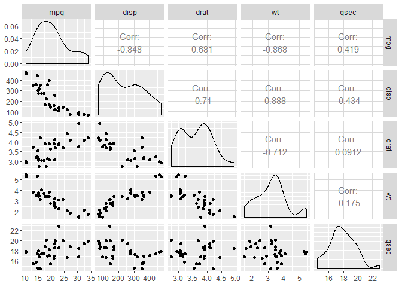

```r
mtcars2 <- mtcars %>%
  select(mpg, disp, drat, wt, qsec)

ggpairs(mtcars2)
```

## Plot Matrix (2)

On the right, another plot matrix is shown based off of a subset of the mtcars data frame. What is the relationship between `disp` and `cyl`? As `cyl` increases, so to does the `disp`.

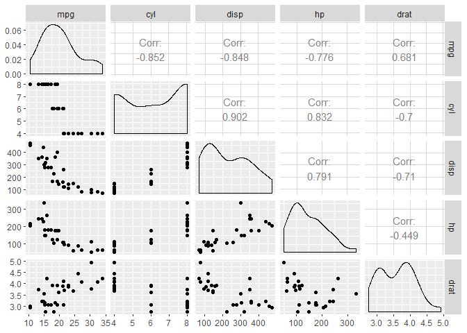

```r
mtcars2 <- mtcars %>%
  select(mpg, cyl, disp, hp, drat)

ggpairs(mtcars2)
```

For more information about the `mtcars` dataset, check out this [report](http://rstudio-pubs-static.s3.amazonaws.com/61800_faea93548c6b49cc91cd0c5ef5059894.html), which explains the meaning of each variable in the `mtcars` dataset.

## Heat Maps

Heat maps are surprisingly popular choice for data visualization, but they are probably one of the least effective types of visualization.

In the video you saw reasons for not using heat maps. Nonetheless, you may encounter a case in which you really do want to use one. Luckily, they’re fairly straightforward to produce in ggplot2.

We begin by specifying two categorical variables for the `x` and `y` aesthetics. At the intersection of each category we’ll draw a box, except here we call it a tile, using the **`geom_tile()`** layer. Then we will fill each tile with a continuous variable.

We’ll produce the heat map we saw in the video with the built-in `barley` dataset. The barley dataset is in the `lattice` package and has already been loaded for you. Begin by exploring the structure of the data in the console using **`str()`**.

```r
# Loading lattice for barley dataset
library(lattice)

data("barley")

head(barley)
```

```
#>      yield   variety year            site
#> 1 27.00000 Manchuria 1931 University Farm
#> 2 48.86667 Manchuria 1931          Waseca
#> 3 27.43334 Manchuria 1931          Morris
#> 4 39.93333 Manchuria 1931       Crookston
#> 5 32.96667 Manchuria 1931    Grand Rapids
#> 6 28.96667 Manchuria 1931          Duluth
```

```r
# Trying out spread from tidyr
barley %>% spread(year, yield)
```

```
#>             variety            site     1932     1931
#> 1          Svansota    Grand Rapids 16.63333 29.66667
#> 2          Svansota          Duluth 22.23333 25.70000
#> 3          Svansota University Farm 27.43334 35.13333
#> 4          Svansota          Morris 35.03333 25.76667
#> 5          Svansota       Crookston 20.63333 40.46667
#> 6          Svansota          Waseca 38.50000 47.33333
#> 7           No. 462    Grand Rapids 19.90000 24.93334
#> 8           No. 462          Duluth 22.50000 28.10000
#> 9           No. 462 University Farm 25.56667 36.60000
#> 10          No. 462          Morris 47.00000 30.36667
#> 11          No. 462       Crookston 30.53333 48.56666
#> 12          No. 462          Waseca 44.70000 65.76670
#> 13        Manchuria    Grand Rapids 22.13333 32.96667
#> 14        Manchuria          Duluth 22.56667 28.96667
```

[output cut: 46 more lines]

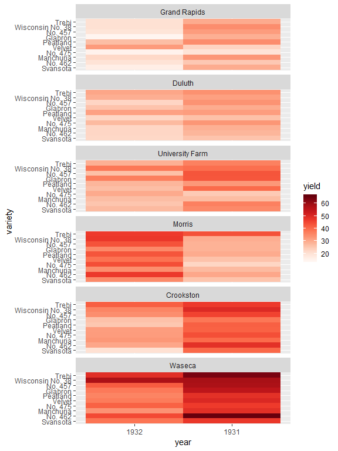

```r
# Create color palette
myColors <- brewer.pal(9, "Reds")

# Build the heat map from scratch
ggplot(barley, aes(x = year, y = variety, fill = yield)) +
  geom_tile() + # Geom layer
  facet_wrap( ~ site, ncol = 1) + # Facet layer
  scale_fill_gradientn(colors = myColors) # Adjust colors
```

Good job! You can continue by using breaks, limits and labels to modify the fill scale and update the theme, but this is a pretty good start.

### Heat Maps Alternatives (1)

There are several alternatives to heat maps. The best choice really depends on the data and the story you want to tell with this data. If there is a time component, the most obvious choice is a line plot like what we see in the viewer. Can you come up with the correct commands to create a similar looking plot?

The barley dataset is already available in the workspace. Feel free to check out its structure before you start!

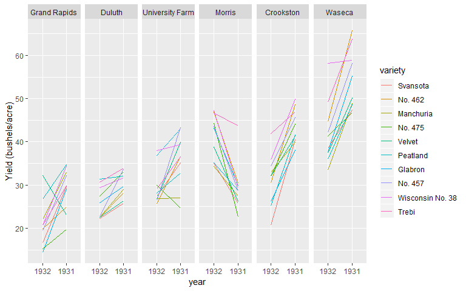

```r
# Line plot; set the aes, geom and facet

ggplot(barley, aes(x = year, y = yield, col = variety, group = variety)) +
  geom_line() +
  ylab("Yield (bushels/acre)") +
  facet_wrap( ~ site, nrow = 1)
```

```r
  # scale_fill_brewer(colors = myColors)
```

Good job! Whenever you see a heat map, ask yourself it it’s really necessary. Many people use them because they look fancy and complicated - signs of poor communication skills.

### Heat Maps Alternatives (2)

In the videos we saw two methods for depicting overlapping measurements of spread. You can use dodged error bars or you can use overlapping transparent ribbons (shown in the viewer). In this exercise we’ll try to recreate the second option, the transparent ribbons.

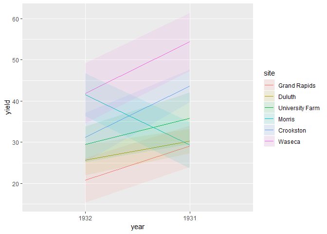

```r
# Create overlapping ribbon plot from scratch

p <- ggplot(barley, aes(x = year, y = yield, col = site, group = site, fill = site)) +
  stat_summary(fun.y = mean,
               geom = "line") +
  stat_summary(fun.data = mean_sdl,
               fun.args = list(mult = 1),
               geom = "ribbon",
               col = NA,
               alpha = 0.1)

p
```

Good job! This concludes the chapter on best practices!